# Credit Card Customer Segmentation

```python
# Drop column
cccs_df_scaled.drop('Kmean_grouping', inplace=True, axis=1)
```

```python
# cophenet index is a measure of the correlation between the distance of points in feature space and distance on dendrogram
# closer it is to 1, the better is the clustering

from scipy.cluster.hierarchy import cophenet, dendrogram, linkage
from scipy.spatial.distance import pdist

links = ['ward', 'complete', 'average', 'single', 'weighted', 'centroid', 'median']
affs = ['braycurtis', 'canberra', 'chebyshev', 'cityblock', 'correlation',
        'cosine', 'dice', 'euclidean', 'hamming', 'jaccard',
        'kulsinski', 'mahalanobis', 'matching', 'minkowski', 'rogerstanimoto',
        'russellrao', 'seuclidean', 'sokalmichener', 'sokalsneath', 'sqeuclidean']

for aff in affs:
    for link in links:
        if link == 'ward' and aff != 'euclidean':
            pass
        elif link == 'centroid' and aff != 'euclidean':
            pass
        elif link == 'median' and aff != 'euclidean':
            pass
        else:
            Z = linkage(cccs_df_scaled[cols], metric=aff, method=link)
            c, coph_dists = cophenet(Z , pdist(cccs_df_scaled[cols]))
            if c > .75:
                print('affinity:',aff, ', link:',link,':', c)
```

```
affinity: braycurtis , link: single : 0.8502845518924395
affinity: canberra , link: single : 0.7566178713003985
affinity: chebyshev , link: complete : 0.8533474836336782
affinity: chebyshev , link: average : 0.8974159511838106
affinity: chebyshev , link: weighted : 0.8913624010768603
affinity: cityblock , link: complete : 0.8731477899179829
affinity: cityblock , link: average : 0.896329431104133
affinity: cityblock , link: weighted : 0.8825520731498188
affinity: euclidean , link: complete : 0.8599730607972423
affinity: euclidean , link: average : 0.8977080867389372
affinity: euclidean , link: weighted : 0.8861746814895477
affinity: euclidean , link: centroid : 0.8939385846326323
affinity: euclidean , link: median : 0.8893799537016724
affinity: mahalanobis , link: average : 0.8326994115042134
affinity: mahalanobis , link: weighted : 0.7805990615142516
affinity: minkowski , link: complete : 0.8599730607972423
affinity: minkowski , link: average : 0.8977080867389372
affinity: minkowski , link: weighted : 0.8861746814895477
affinity: seuclidean , link: complete : 0.8599730607972426
affinity: seuclidean , link: average : 0.8977080867389373
affinity: seuclidean , link: weighted : 0.8861746814895477
affinity: sqeuclidean , link: complete : 0.8820964814996479
affinity: sqeuclidean , link: average : 0.8783309583061251
affinity: sqeuclidean , link: weighted : 0.893679734763713
```

```python
# Calculate Silhouette Score

from sklearn.cluster import AgglomerativeClustering

meanDistortions=[]

for k in range(2, 10):
    model=AgglomerativeClustering(n_clusters=k, affinity='euclidean',  linkage='average')
    model.fit(cccs_df_scaled)
    prediction=model.labels_
    meanDistortions.append(silhouette_score(cccs_df_scaled, prediction))

silhouette_score(cccs_df_scaled, prediction)
```

```
0.3415486932890892
```

```python
# Visualize Silhoutte score

plt.plot(range(2, 10), meanDistortions, 'bx-')
plt.xlabel('k')
plt.ylabel('silhouette score')
plt.title('Selecting k with silhouette score:');
```

[output not shown]

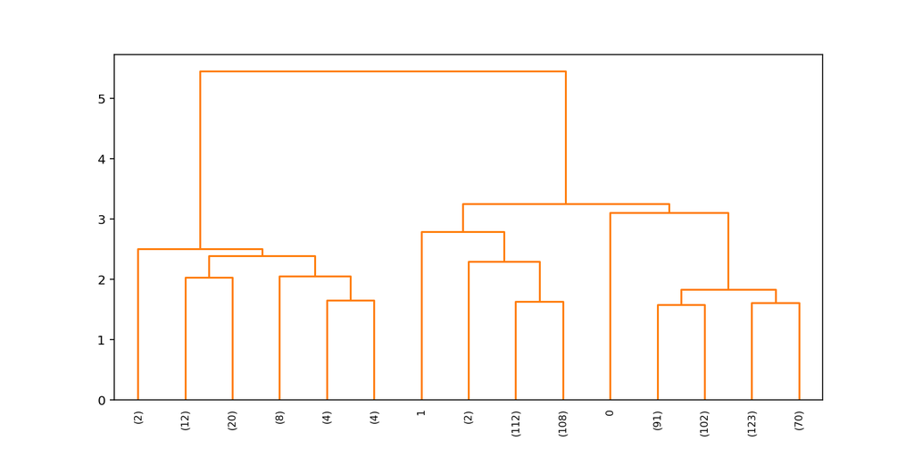

```python
# Visualize Dendogram

Z = linkage(cccs_df_scaled[cols], metric='euclidean', method='average')
c, coph_dists = cophenet(Z , pdist(cccs_df_scaled[cols]))
plt.figure(figsize=(10, 5))

dendrogram(Z, p=15, truncate_mode='lastp', leaf_rotation=90.,color_threshold = 40, leaf_font_size=8.)
plt.show()
```

```python
# Calculating 2 clusters will be more ideal and show the hierarchial clusters count

model=AgglomerativeClustering(n_clusters=2, affinity='euclidean',  linkage='average')
model.fit(cccs_df_scaled)
preds=model.labels_
cccs_df['hc_grouping'] = preds
cccs_df_scaled['hc_grouping'] = preds
cccs_df.groupby('hc_grouping').count()
```

| hc_grouping | Customer Key | Avg_Credit_Limit | Total_Credit_Cards | Total_visits_bank | Total_visits_online | Total_calls_made | Kmean_grouping |
| --- | --- | --- | --- | --- | --- | --- | --- |
| 0 | 610 | 610 | 610 | 610 | 610 | 610 | 610 |
| 1 | 50 | 50 | 50 | 50 | 50 | 50 | 50 |

```python
#  online user segment matches the same online user segment from Kmeans. Online users have more credit cards and a larger credit limit.

cccs_hc = cccs_df.groupby('hc_grouping').mean().append(pd.DataFrame(cccs_df.std()).T)
cccs_hc.index=['Offline','Online', 'Mean']
cccs_hc
```

[output not shown]

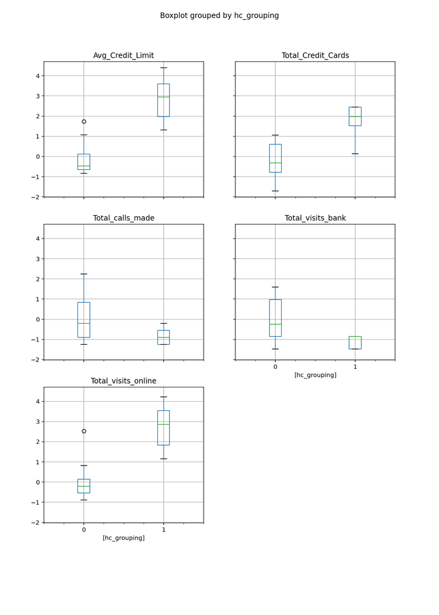

```python
# Visualize Box plot by HC grouping
cccs_df_scaled.boxplot(by='hc_grouping', layout=(3,2), figsize=(10,14));
```

#### How many different segments of customers are there?

#### How are these segments different from each other?

#### What are your recommendations to the bank on how to better market to and service these customers?

Online/phone users will probably prefer email/text notifications, while in-person users prefer mail notifications and upselling (when at the bank location). Since online users tend to have the most credit and we may want to target with our next ad campaign and focusing on digit recruiting. Below we have 5 sets of records for customers with entries that have changed over time, we can see that in three of the five cases of customers have moved from one cluster to another by referring Kmean grouping.

```python
cccs_ds_duplicates = cccs_df.groupby('Customer Key').count()
print('There are',cccs_ds_duplicates.loc[cccs_ds_duplicates.Total_calls_made >=2].shape[0], 'duplicate entries for Customer Key')

for k in list(cccs_ds_duplicates.loc[cccs_ds_duplicates.Total_calls_made >=2].index):
    display(cccs_df.loc[cccs_df['Customer Key'] == k])
```

```
There are 5 duplicate entries for Customer Key
```

| Sl_No | Customer Key | Avg_Credit_Limit | Total_Credit_Cards | Total_visits_bank | Total_visits_online | Total_calls_made | Kmean_grouping | hc_grouping |
| --- | --- | --- | --- | --- | --- | --- | --- | --- |
| 49 | 37252 | 6000 | 4 | 0 | 2 | 8 | 0 | 0 |
| 433 | 37252 | 59000 | 6 | 2 | 1 | 2 | 1 | 0 |

| Sl_No | Customer Key | Avg_Credit_Limit | Total_Credit_Cards | Total_visits_bank | Total_visits_online | Total_calls_made | Kmean_grouping | hc_grouping |
| --- | --- | --- | --- | --- | --- | --- | --- | --- |
| 5 | 47437 | 100000 | 6 | 0 | 12 | 3 | 2 | 1 |
| 333 | 47437 | 17000 | 7 | 3 | 1 | 0 | 1 | 0 |

| Sl_No | Customer Key | Avg_Credit_Limit | Total_Credit_Cards | Total_visits_bank | Total_visits_online | Total_calls_made | Kmean_grouping | hc_grouping |
| --- | --- | --- | --- | --- | --- | --- | --- | --- |
| 412 | 50706 | 44000 | 4 | 5 | 0 | 2 | 1 | 0 |
| 542 | 50706 | 60000 | 7 | 5 | 2 | 2 | 1 | 0 |

| Sl_No | Customer Key | Avg_Credit_Limit | Total_Credit_Cards | Total_visits_bank | Total_visits_online | Total_calls_made | Kmean_grouping | hc_grouping |
| --- | --- | --- | --- | --- | --- | --- | --- | --- |
| 392 | 96929 | 13000 | 4 | 5 | 0 | 0 | 1 | 0 |
| 399 | 96929 | 67000 | 6 | 2 | 2 | 2 | 1 | 0 |

| Sl_No | Customer Key | Avg_Credit_Limit | Total_Credit_Cards | Total_visits_bank | Total_visits_online | Total_calls_made | Kmean_grouping | hc_grouping |
| --- | --- | --- | --- | --- | --- | --- | --- | --- |
| 105 | 97935 | 17000 | 2 | 1 | 2 | 10 | 0 | 0 |
| 633 | 97935 | 187000 | 7 | 1 | 7 | 0 | 2 | 1 |